# STAT565 Homework

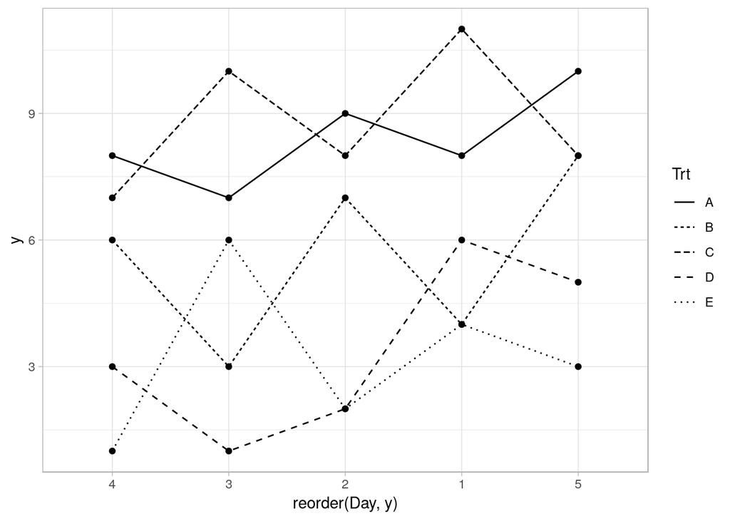

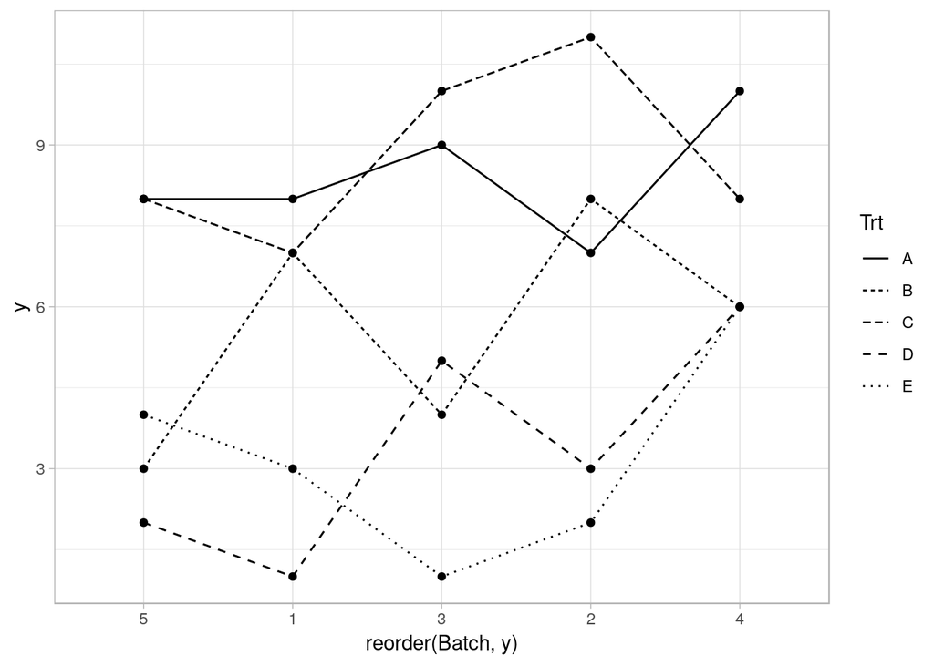

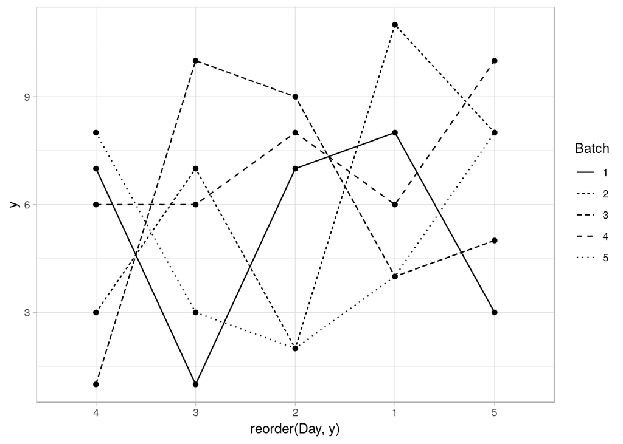

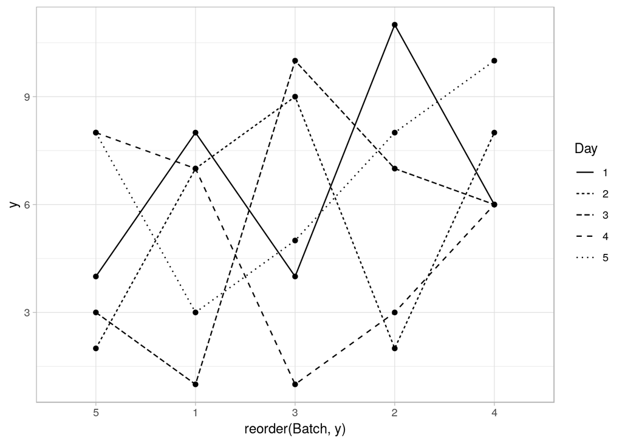

2. Obtain the ANOVA table for this study and report it here.

```
##             Df Sum Sq Mean Sq F value   Pr(>F)
## Trt          4 141.44   35.36  11.309 0.000488 ***
## Day          4  12.24    3.06   0.979 0.455014
## Batch        4  15.44    3.86   1.235 0.347618
## Residuals   12  37.52    3.13
## ---
## Signif. codes:  0 '***' 0.001 '**' 0.01 '*' 0.05 '.' 0.1 ' ' 1
```

3. Test whether ingredients have a significant effect on the reaction time at α=0.05. Report your conclusion and p value here.

Set the overall hypotheses are $H_0: \mu_1=\mu_2=\mu_3=\mu_4=\mu_5$ or $\tau_1=\tau_2=\tau_3=\tau_4=\tau_5$ versus $H_1$: At least two of $\mu_i$’s are different or At least one $\tau_i\neq0$

The ANOVA for Latin-square shows that the P-value of 0.000488 for treatment is small enough. We can reject the $H_0$ and conclude that the ingredients have significant effects on the average values of reaction time at 0.05 significant level.

4. Test the significance of different batches of material at α=0.05. Report your conclusion and p value here.

Set the hypotheses are $H_0: \beta_1=\beta_2=\beta_3=\beta_4=\beta_5$ versus $H_1$: At least two of $\beta_k$’s are different.

The reaults of ANOVA show that the P-value of overall batches effects is 0.347618. TukeyLSD test show that the P-value of all the paired comparing among batches is large enough. All of the confident intervals include zero. We cannot reject $H_0$. There is not significant difference on the average values of reaction time among the batches at 0.05 significant level.

|  | diff | lwr | upr | p adj |
| --- | --- | --- | --- | --- |
| 2-1 | 1.0 | -2.564608 | 4.564608 | 0.8936609 |
| 3-1 | 0.6 | -2.964608 | 4.164608 | 0.9816047 |
| 4-1 | 2.0 | -1.564608 | 5.564608 | 0.4225127 |
| 5-1 | -0.2 | -3.764608 | 3.364608 | 0.9997349 |
| 3-2 | -0.4 | -3.964608 | 3.164608 | 0.9960012 |
| 4-2 | 1.0 | -2.564608 | 4.564608 | 0.8936609 |
| 5-2 | -1.2 | -4.764608 | 2.364608 | 0.8166339 |
| 4-3 | 1.4 | -2.164608 | 4.964608 | 0.7232162 |
| 5-3 | -0.8 | -4.364608 | 2.764608 | 0.9489243 |
| 5-4 | -2.2 | -5.764608 | 1.364608 | 0.3365811 |

5. Provide all the necessary residual plots here and use them to explain whether assumptions about the model for this design are valid or not.

The histogram of residuals does not detect obvious violation of normality assumption.

The plot of studentized residual versus predicted (fitted) value shows that except few outliers, the residuals are evenly distributed about zero at each prededict value (zero mean) and vertical deviations of residuals from zero are about same for each predicted value (constant variance).

The plots of studentized residual versus factor levels didn’t show obvious violation of zero mean and constant variance.

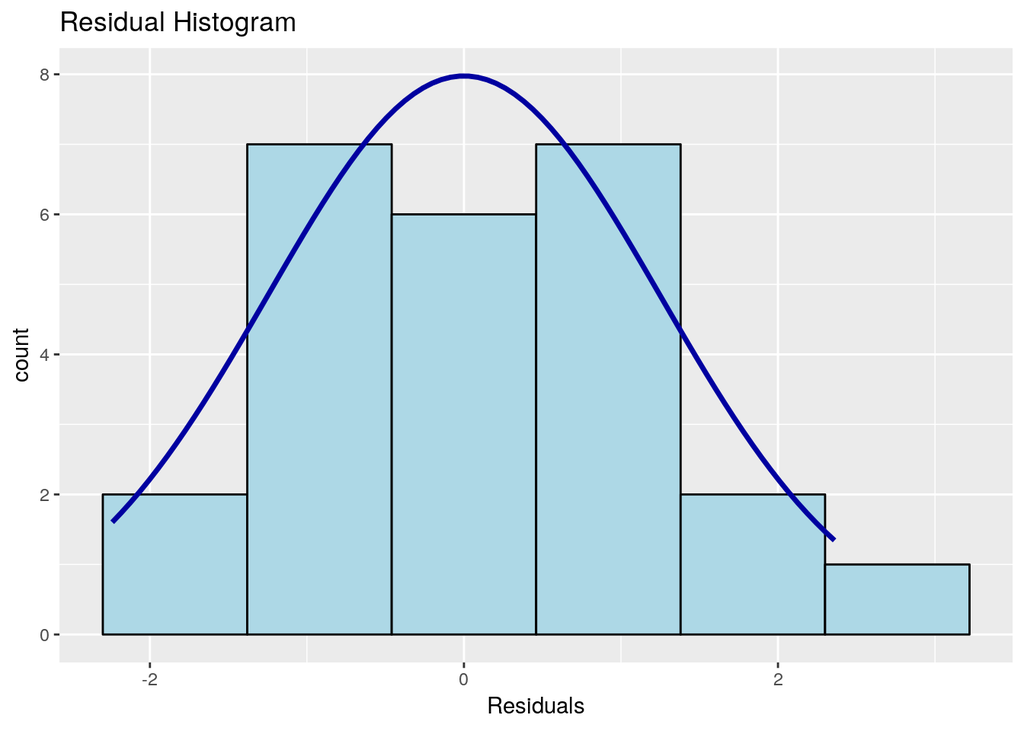

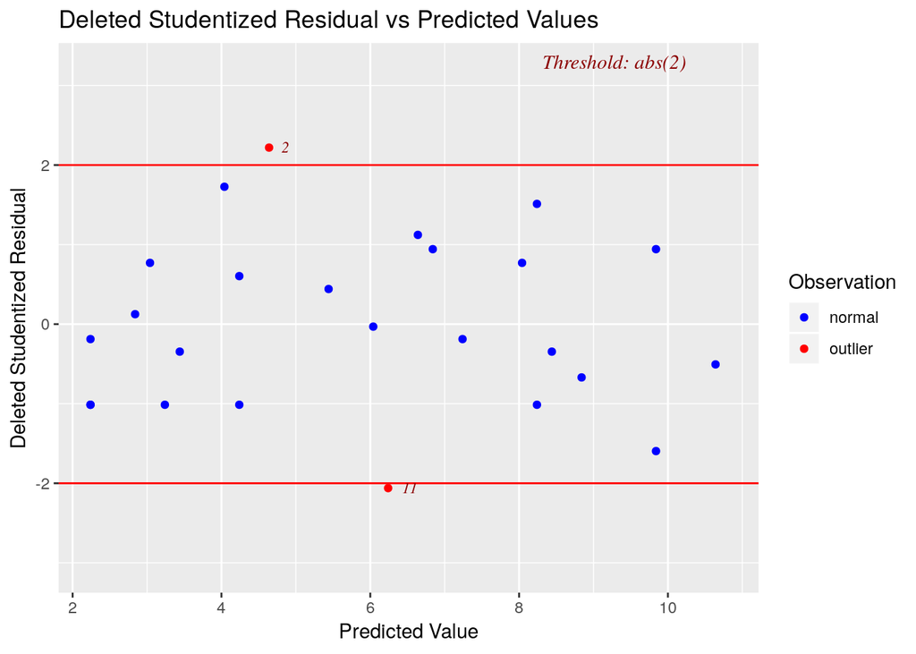

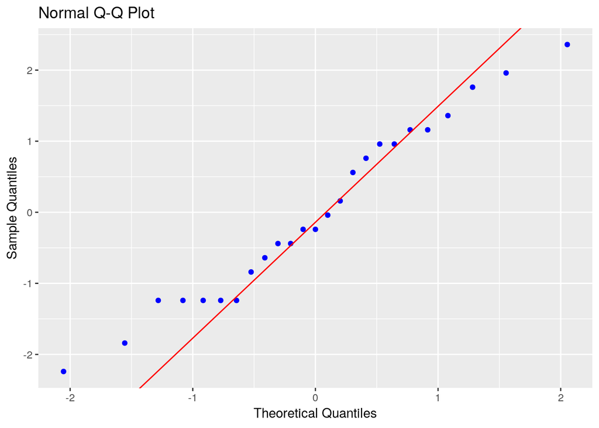

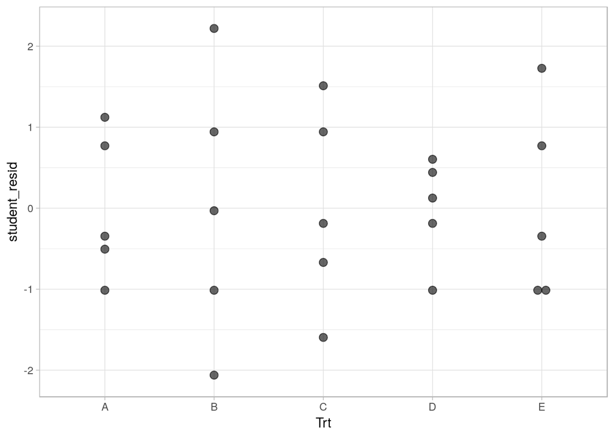

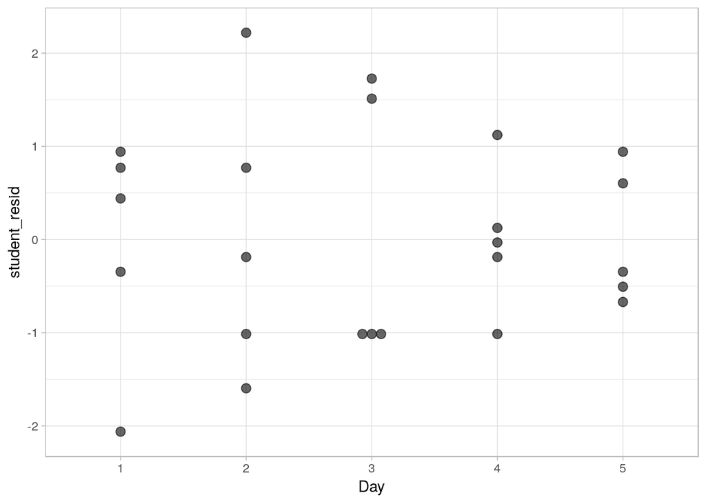

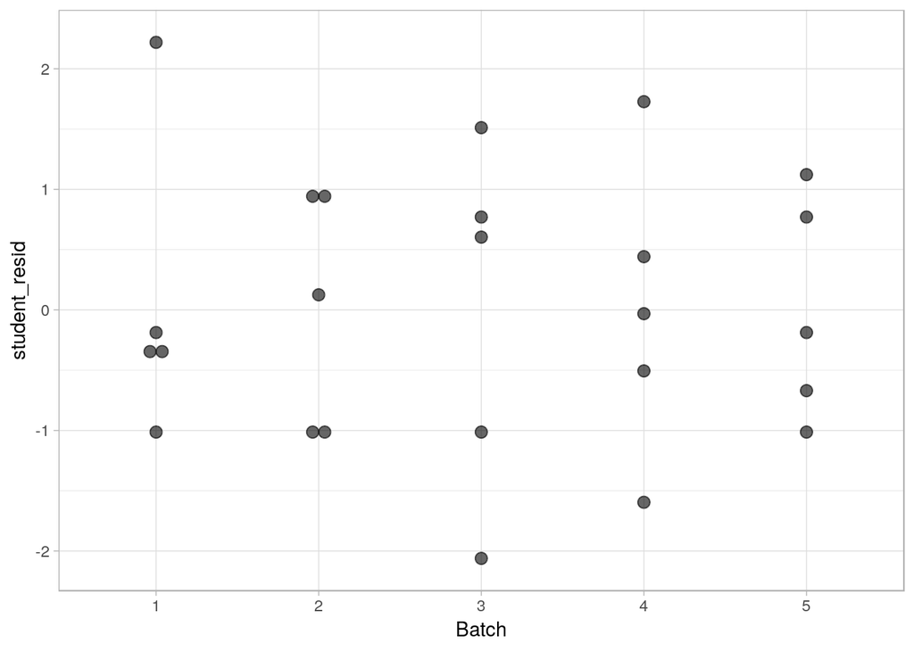

6. Report the complete code along with output here.

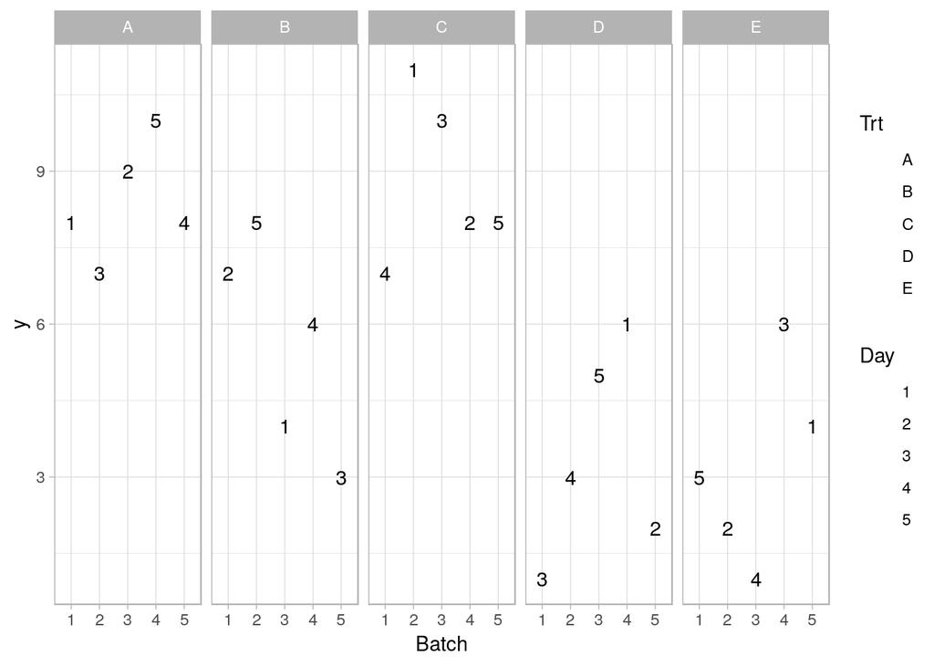

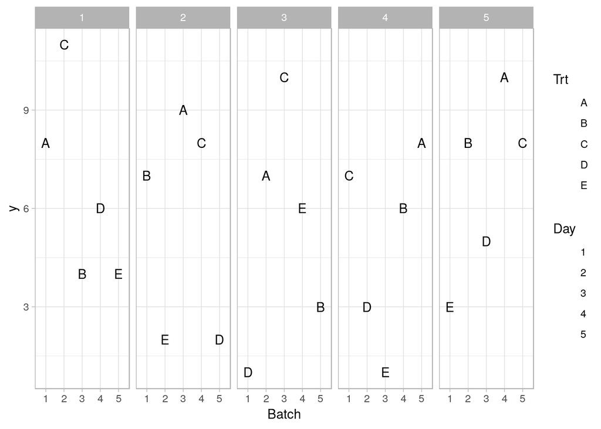

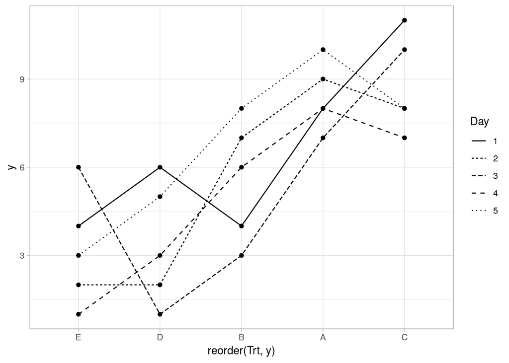

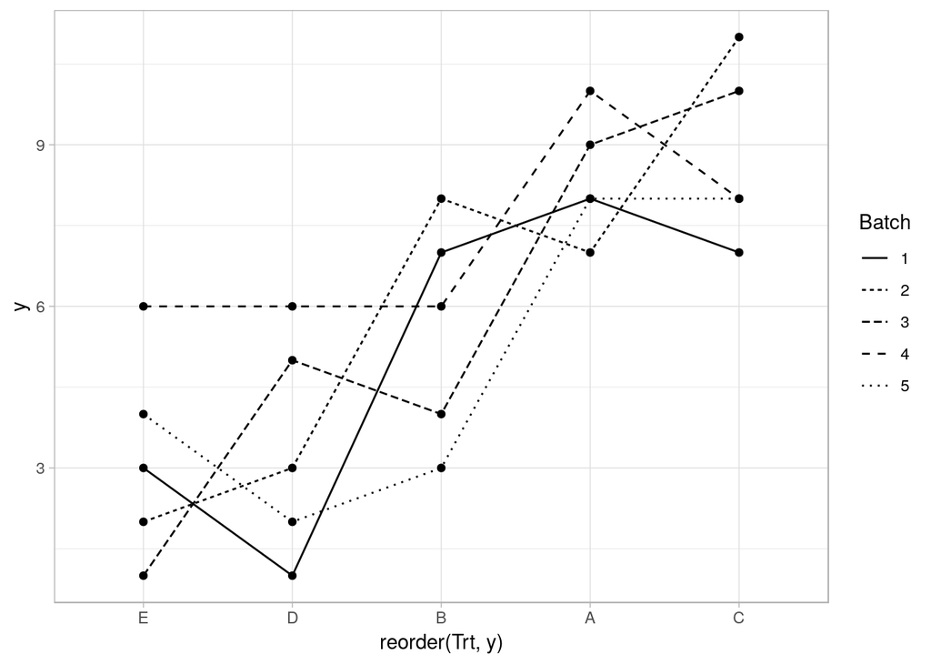

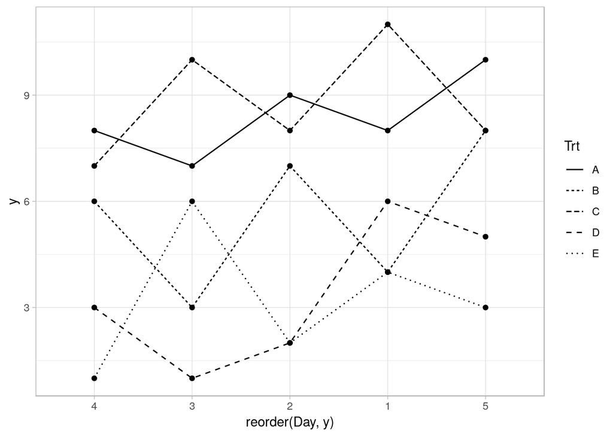

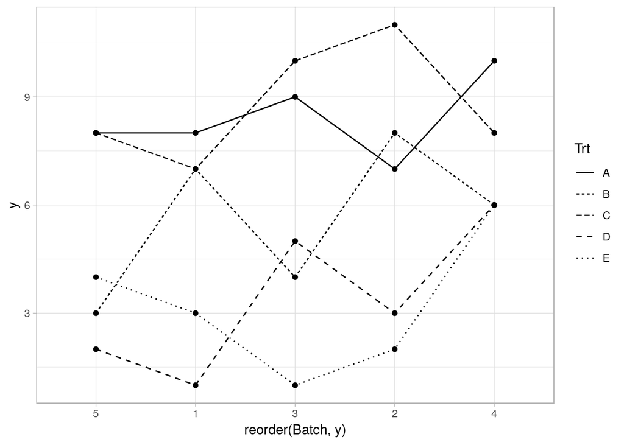

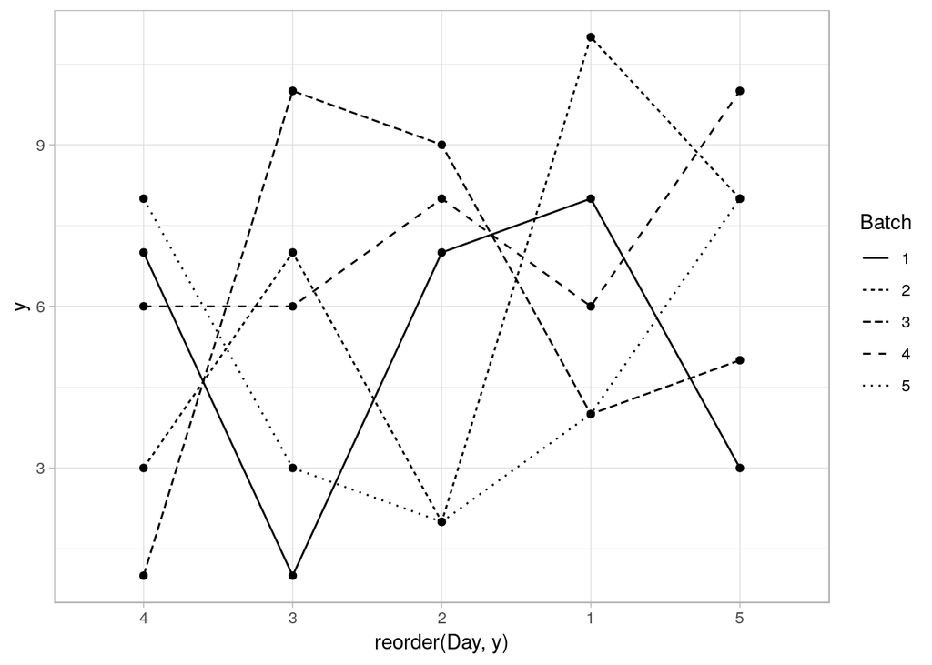

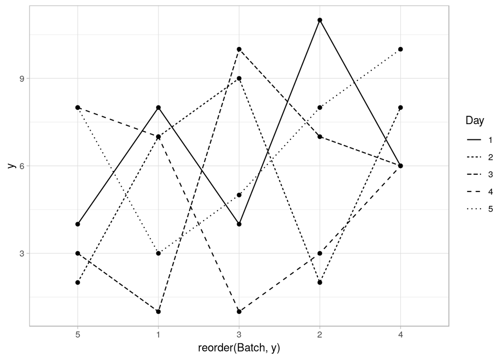

```r
# (a)
table_ingredients <- read_xlsx("Exercise4_22.xlsx");  table_ingredients$Day <- as.factor(table_ingredients$Day)
table_ingredients$Batch <- as.factor(table_ingredients$Batch);  table_ingredients$Trt <- as.factor(table_ingredients$Trt)
glimpse(table_ingredients)
## Observations: 25
## Variables: 4
## $ Batch <fct> 1, 1, 1, 1, 1, 2, 2, 2, 2, 2, 3, 3, 3, 3, 3, 4, 4, 4, 4,...
## $ Day   <fct> 1, 2, 3, 4, 5, 1, 2, 3, 4, 5, 1, 2, 3, 4, 5, 1, 2, 3, 4,...
## $ Trt   <fct> A, B, D, C, E, C, E, A, D, B, B, A, C, E, D, D, C, E, B,...
## $ y     <dbl> 8, 7, 1, 7, 3, 11, 2, 7, 3, 8, 4, 9, 10, 1, 5, 6, 8, 6, ...
table_ingredients%>%ggplot(aes(Batch,y))+geom_point(aes(shape=Day,col=Trt),alpha=0)+geom_text(aes(label=Day))+facet_grid(.~Trt)+theme_light()
table_ingredients%>%ggplot(aes(Batch,y))+geom_point(aes(shape=Day,col=Trt),alpha=0)+geom_text(aes(label=Trt))+facet_grid(.~Day)+theme_light()
qplot(reorder(Trt,y),y,data=table_ingredients)+geom_line(aes(group=Day,lty=Day))+theme_light()
qplot(reorder(Trt,y),y,data=table_ingredients)+geom_line(aes(group=Batch,lty=Batch))+theme_light()
qplot(reorder(Day,y),y,data=table_ingredients)+geom_line(aes(group=Trt,lty=Trt))+theme_light()
qplot(reorder(Batch,y),y,data=table_ingredients)+geom_line(aes(group=Trt,lty=Trt))+theme_light()
qplot(reorder(Day,y),y,data=table_ingredients)+geom_line(aes(group=Batch,lty=Batch))+theme_light()
qplot(reorder(Batch,y),y,data=table_ingredients)+geom_line(aes(group=Day,lty=Day))+theme_light()
```

```r
# (b)
model_ingredients <- aov(y~Trt+Day+Batch,data =table_ingredients)
summary(model_ingredients)
##             Df Sum Sq Mean Sq F value   Pr(>F)
## Trt          4 141.44   35.36  11.309 0.000488 ***
## Day          4  12.24    3.06   0.979 0.455014
## Batch        4  15.44    3.86   1.235 0.347618
## Residuals   12  37.52    3.13
## ---
## Signif. codes:  0 '***' 0.001 '**' 0.01 '*' 0.05 '.' 0.1 ' ' 1
```

```r
# (d)
TukeyHSD(model_ingredients,conf.level = 0.95)
##   Tukey multiple comparisons of means
##     95% family-wise confidence level
##
## Fit: aov(formula = y ~ Trt + Day + Batch, data = table_ingredients)
##
## $Trt
##     diff        lwr        upr     p adj
## B-A -2.8 -6.3646078  0.7646078 0.1539433
## C-A  0.4 -3.1646078  3.9646078 0.9960012
## D-A -5.0 -8.5646078 -1.4353922 0.0055862
## E-A -5.2 -8.7646078 -1.6353922 0.0041431
## C-B  3.2 -0.3646078  6.7646078 0.0864353
## D-B -2.2 -5.7646078  1.3646078 0.3365811
## E-B -2.4 -5.9646078  1.1646078 0.2631551
## D-C -5.4 -8.9646078 -1.8353922 0.0030822
## E-C -5.6 -9.1646078 -2.0353922 0.0023007
## E-D -0.2 -3.7646078  3.3646078 0.9997349
##
## $Day
##     diff       lwr      upr     p adj
## 2-1 -1.0 -4.564608 2.564608 0.8936609
## 3-1 -1.2 -4.764608 2.364608 0.8166339
## 4-1 -1.6 -5.164608 1.964608 0.6212723
## 5-1  0.2 -3.364608 3.764608 0.9997349
## 3-2 -0.2 -3.764608 3.364608 0.9997349
## 4-2 -0.6 -4.164608 2.964608 0.9816047
## 5-2  1.2 -2.364608 4.764608 0.8166339
## 4-3 -0.4 -3.964608 3.164608 0.9960012
## 5-3  1.4 -2.164608 4.964608 0.7232162
## 5-4  1.8 -1.764608 5.364608 0.5188508
##
## $Batch
##     diff       lwr      upr     p adj
## 2-1  1.0 -2.564608 4.564608 0.8936609
## 3-1  0.6 -2.964608 4.164608 0.9816047
## 4-1  2.0 -1.564608 5.564608 0.4225127
## 5-1 -0.2 -3.764608 3.364608 0.9997349
## 3-2 -0.4 -3.964608 3.164608 0.9960012
## 4-2  1.0 -2.564608 4.564608 0.8936609
## 5-2 -1.2 -4.764608 2.364608 0.8166339
## 4-3  1.4 -2.164608 4.964608 0.7232162
## 5-3 -0.8 -4.364608 2.764608 0.9489243
## 5-4 -2.2 -5.764608 1.364608 0.3365811
```

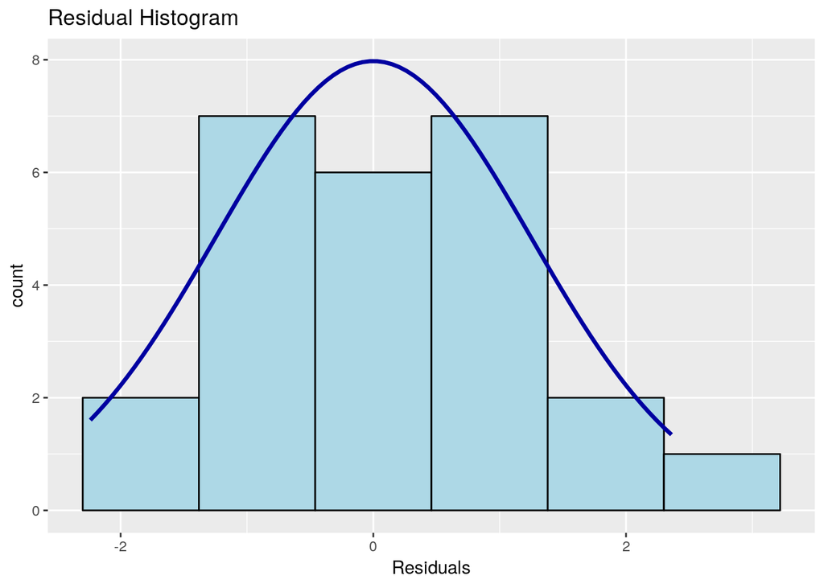

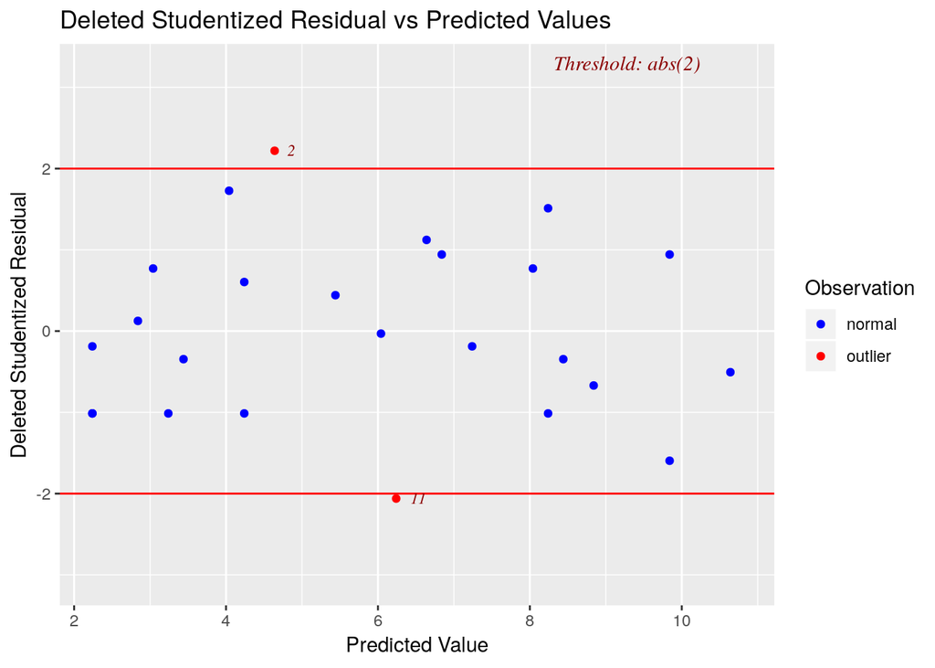

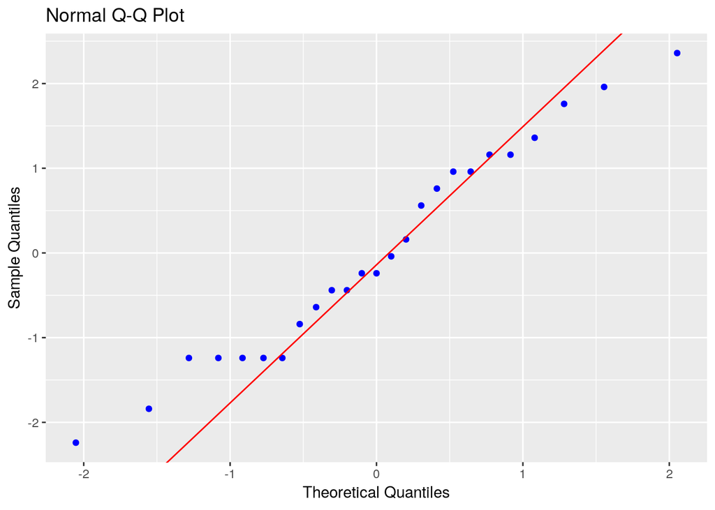

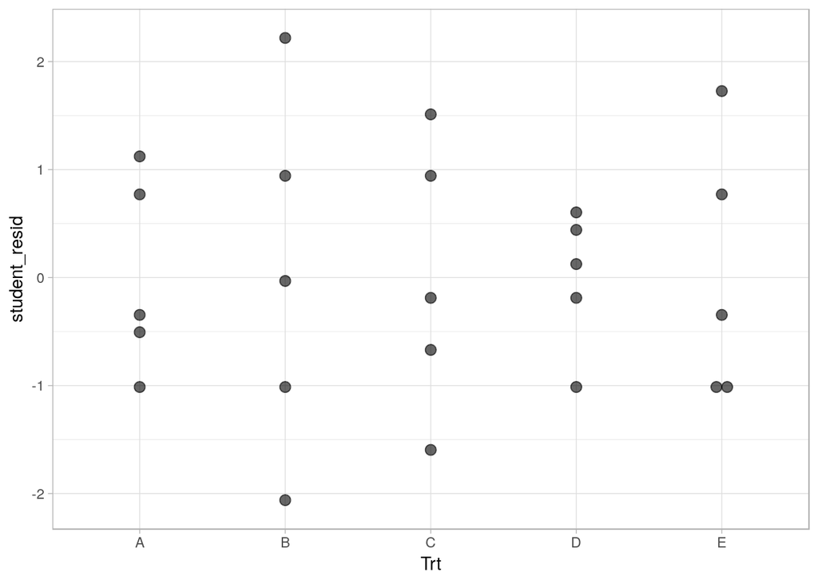

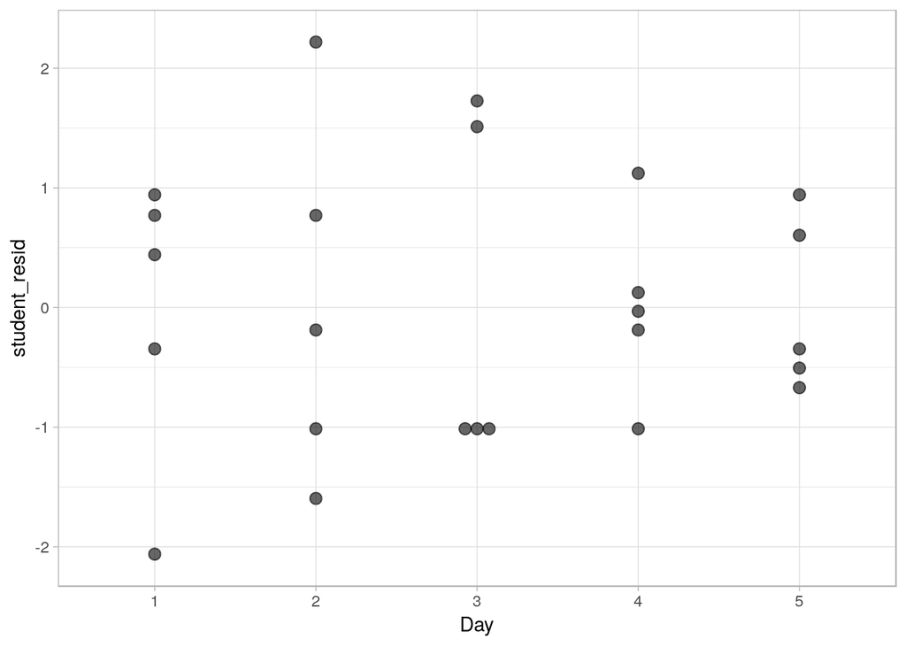

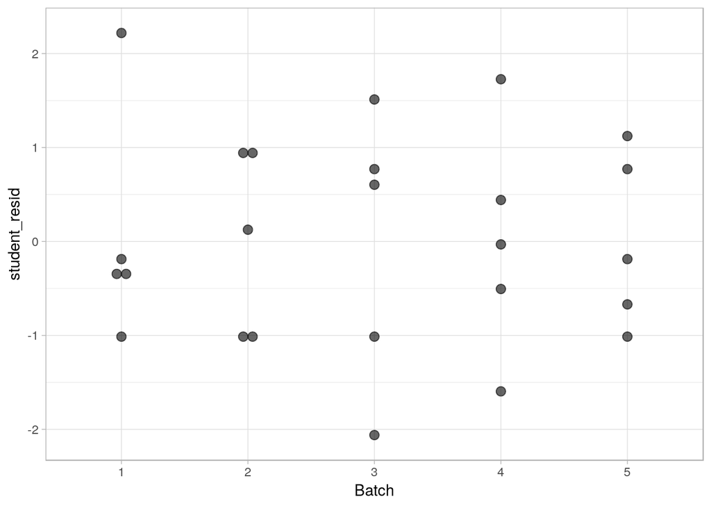

```r
# (e)
table_ingredients$student_resid <- rstudent(model_ingredients)
ols_plot_resid_hist(lm(y~Trt+Day+Batch,data =table_ingredients))
ols_plot_resid_stud_fit(lm(y~Trt+Day+Batch,data =table_ingredients))
ols_plot_resid_qq(lm(y~Trt+Day+Batch,data =table_ingredients))
ggplot(table_ingredients,aes(Trt,student_resid))+geom_dotplot(binaxis = "y", stackdir = "center",binwidth=0.1,alpha=0.6)+theme_light()
ggplot(table_ingredients,aes(Day,student_resid))+geom_dotplot(binaxis = "y", stackdir = "center",binwidth=0.1,alpha=0.6)+theme_light()
ggplot(table_ingredients,aes(Batch,student_resid))+geom_dotplot(binaxis = "y", stackdir = "center",binwidth=0.1,alpha=0.6)+theme_light()
```

### Problem 3:

The data below are from a replicated Latin Square with 4 treatments: row blocks were reused, but column blocks were not.

```
## Observations: 32
## Variables: 5
## $ Replicate <fct> 1, 1, 1, 1, 1, 1, 1, 1, 1, 1, 1, 1, 1, 1, 1, 1, 2, 2...
## $ Row       <fct> 1, 1, 1, 1, 2, 2, 2, 2, 3, 3, 3, 3, 4, 4, 4, 4, 1, 1...
## $ Col       <fct> 1, 2, 3, 4, 1, 2, 3, 4, 1, 2, 3, 4, 1, 2, 3, 4, 5, 6...
## $ Trt       <fct> D, C, B, A, B, A, D, C, C, D, A, B, A, B, C, D, B, C...
## $ y         <dbl> 44, 39, 52, 73, 26, 45, 49, 58, 67, 71, 81, 76, 77, ...
```

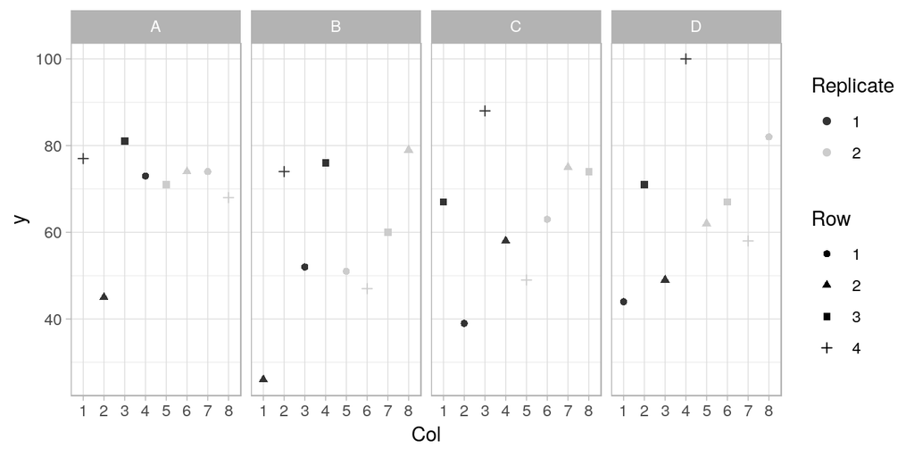

1. Obtain the ANOVA table for this study and report it here.

```
##               Df Sum Sq Mean Sq F value Pr(>F)
## Trt            3    635   211.8   0.951  0.437
## Row            3   1044   347.9   1.562  0.233
## Replicate      1     36    36.1   0.162  0.692
## Replicate:Col  6   1986   331.0   1.486  0.239
## Residuals     18   4010   222.8
```

2. Test whether treatments are statistically significant at α=0.01. Report your conclusion and p value here.

Set the overall hypotheses are $H_0: \mu_1=\mu_2=\mu_3=\mu_4$ or $\tau_1=\tau_2=\tau_3=\tau_4$ versus $H_1$: At least two of $\mu_i$’s are different or At least one $\tau_i\neq0$.

The ANOVA for replicated Latin-square shows that the P-value of 0.437 for treatment is larger than 0.01. We cannot reject $H_0$. The treatments have not significant effects on the average values of resopnse variable at 0.01 significant level.

### Problem 4:

The BIBD model with fixed effect is:$y_{ij}=μ+τ_i+β_j+ε_{ij}$,for i=1,2,…,a$;$j=1,2,…,b; $N=kb=ra≠ab$. $ε_{ij} ~ iidN(0,σ^2)$;$\sum_{i=1}^aτ_i=0$ and $\sum_{j=1}^bβ_j =0$; $y_{i.}=\sum_jy_{ij}$,$\bar y_{.j}=\frac1k\sum_iy_{ij}=\frac{y_{.j}}k$. Let $Q_i=(y_{i.}-\sum_{j=1}^bn_{ij}\bar y_{.j})$ where $n_{ij}=\begin{cases}1& \text{if } i^{th} \text{ treatment appears in } j^{th}\text{ block}\\0&\text{Otherwise}\end{cases}$ Prove that $\sum_{i=1}^aQ_i=0$

$$\sum_{i=1}^aQ_i=\sum_{i=1}^a[y_{i.}-\sum_{j=1}^bn_{ij}\bar y_{.j}]=\sum_{i=1}^a\sum_{j=1}^b y_{ij}-\sum_{j=1}^b(\bar y_{.j}\sum_{i=1}^an_{ij})=y_{..}-\sum_{j=1}^b(\frac{y_{.j}}kk)=y_{..}-y_{..}=0$$

### Problem 5:

Consider the two-factor factorial model with fixed effects: $y_{ijk}=μ+τ_i+β_j+(τβ)_{ij}+ε_{ijk}$, for $i=1,2,…,a$; $j=1,2,…,b$; $k=1,2,…,n$ $ε_{ijk}\sim iid N(0,σ^2)$;$\sum_{i=1}^aτ_i=0$ and $\sum_{j=1}^bβ_j=0$; $\sum_{i=1}^a(τβ)_{ij}=0$ and $\sum_{j=1}^b(τβ)_{ij}=0$ $\bar y_{i..}=\frac1{bn}\sum_{j=1}^b\sum_{k=1}^ny_{ijk}$; $y_{...}=\sum_{i=1}^a\sum_{j=1}^b\sum_{k=1}^ny_{ijk}$; $\bar y_{...}=\frac{y_{...}}N$. Compute the $E(SS_A)$ where $SS_A=bn\sum_{i=1}^a(\bar y_{i..}-\bar y_{...})^2$

- For $i=1,2,…,a$; $j=1,2,…,b$; $k=1,2,…,n$, for $\sum_{i=1}^aτ_i=0$, $\sum_{j=1}^bβ_j=0$; $\sum_{i=1}^a(τβ)_{ij}=0$, and $\sum_{j=1}^b(τβ)_{ij}=0$,

$\bar y_{i..}-\bar y_{...}=\frac1{bn}\sum\limits_{j=1}^b\sum\limits_{k=1}^n(μ+τ_i+β_j+(τβ)_{ij}+ε_{ijk})-\frac1{abn}\sum\limits_{i=1}^a\sum\limits_{j=1}^b\sum\limits_{k=1}^n(μ+τ_i+β_j+(τβ)_{ij}+ε_{ijk})$

$=μ+τ_i+\frac1{b}\sum\limits_{j=1}^bβ_j+\frac1{b}\sum\limits_{j=1}^b(τβ)_{ij}+\frac1{bn}\sum\limits_{j=1}^b\sum\limits_{k=1}^nε_{ijk}-μ-\frac1{a}\sum\limits_{i=1}^aτ_i-\frac1{b}\sum\limits_{j=1}^bβ_j-\frac1{ab}\sum\limits_{i=1}^a\sum\limits_{j=1}^b(τβ)_{ij}-\frac1{abn}\sum\limits_{i=1}^a\sum\limits_{j=1}^b\sum\limits_{k=1}^nε_{ijk}$

$=τ_i+\frac1{bn}\sum_{j=1}^b\sum_{k=1}^nε_{ijk}-\frac1{abn}\sum_{i=1}^a\sum_{j=1}^b\sum_{k=1}^nε_{ijk}=τ_i+\bar ε_{i..}-\bar ε_{ijk}$

- For $τ_i$ is a constant of the $i^th$ treatment, $E{τ_i}=τ_i,V{τ_i}=0$, for $ε_{ijk}\sim iidN(0,σ^2)$, $E[ε_{ijk}]=0$

$E[\bar y_{i..}-\bar y_{...}]=E[τ_i+\bar ε_{i..}-\bar ε_{ijk}]=τ_i+\frac1{bn}\sum_{j=1}^b\sum_{k=1}^nE[ε_{ijk}]-\frac1{abn}\sum_{i=1}^a\sum_{j=1}^b\sum_{k=1}^nE[ε_{ijk}]=\tau_i$

- For $τ_i$ and $ε_{ijk}$ are independent. $Cov\left[τ_i,\bar ε_{i..}\right]=Cov[τ_i,\bar ε_{...}]=0$, for $ε_{ijk}\sim iidN(0,σ^2)$, $Cov\left[ε_{ijk},\sum_{i=1}^aε_{ijk}\right]=\sigma^2$

$V[\bar y_{i..}-\bar y_{...}]=$

$$V[τ_i+\bar ε_{i..}-\bar ε_{ijk}]=V[\tau_i]+V[\frac1{bn}{\sum\limits_{j=1}^b\sum\limits_{k=1}^nε_{ijk}}]+V[\frac1{abn}{\sum\limits_{i=1}^a\sum\limits_{j=1}^b\sum\limits_{k=1}^nε_{ijk}}]+2Cov[τ_i,\bar ε_{i..}]-2Cov[τ_i,\bar ε_{...}]-2Cov[\bar ε_{i..},\bar ε_{...}]$$

$=0+\frac{σ^2}{bn}+\frac{σ^2}{abn}+0-0-2Cov\left[\frac1{bn}{\sum\limits_{j=1}^b\sum\limits_{k=1}^nε_{ijk}},\frac1{abn}{\sum\limits_{i=1}^a\sum\limits_{j=1}^b\sum\limits_{k=1}^nε_{ijk}}\right]=\frac{σ^2}{bn}+\frac{σ^2}{abn}-\frac{2}{ab^2n^2}\sum\limits_{j=1}^b\sum\limits_{k=1}^nCov[ε_{ijk},\sum\limits_{i=1}^aε_{ijk}]$

$=\frac{σ^2}{bn}+\frac{σ^2}{abn}-\frac{2}{ab^2n^2}\sum\limits_{j=1}^b\sum\limits_{k=1}^nσ^2=\frac{a-1}{abn}σ^2$

- For $E[X^2]=E[X]^2+V[X]$, therefore,

$$E[SS_A]=bn\sum_{i=1}^aE[(\bar y_{i..}-\bar y_{...})^2]=bn\sum_{i=1}^a(E[\bar y_{i..}-\bar y_{...}]^2+V[\bar y_{i..}-\bar y_{...}])=bn\sum_{i=1}^a(\tau_i^2+\frac{a-1}{abn}σ^2)=bn\sum_{i=1}^aτ_i^2+(a-1)σ^2$$